# Exploratory data analysis on Prosper Loan Dataset by Joy Lal Chattaraj

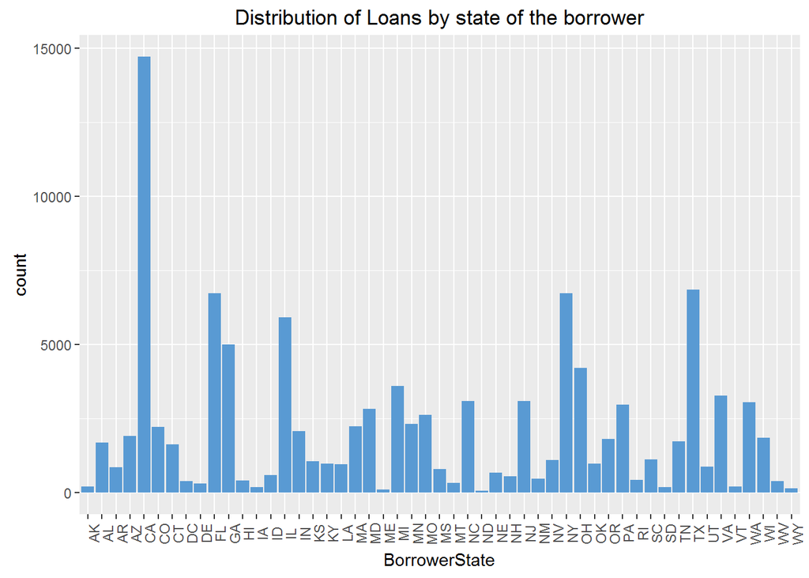

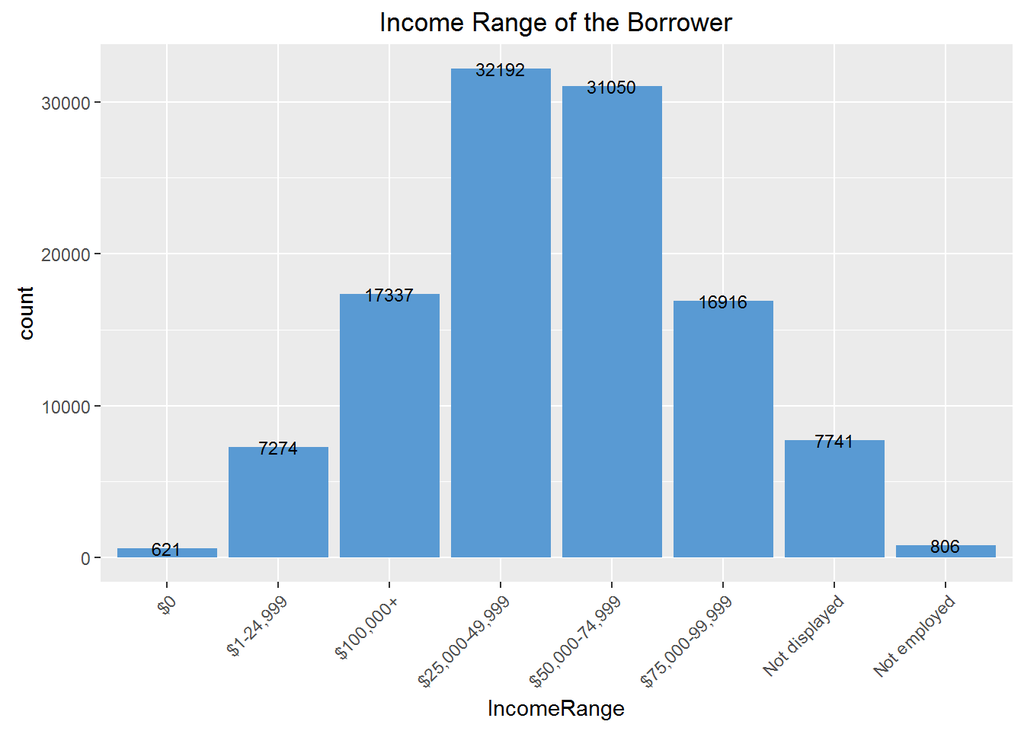

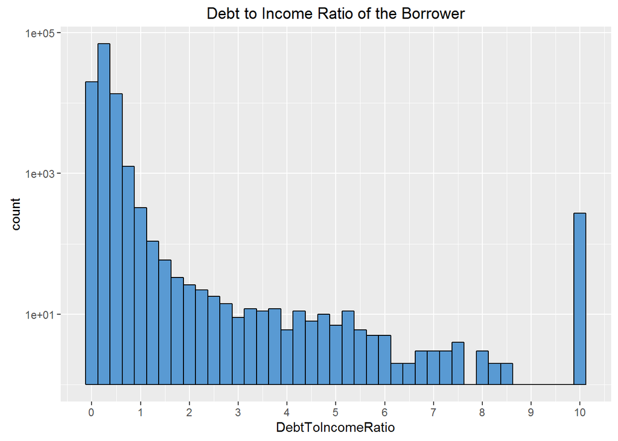

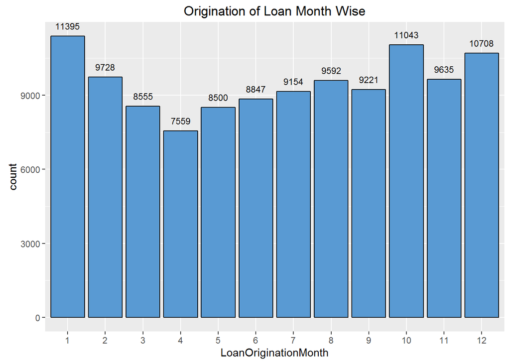